# A Hitchhiker’s Guide to R

Sam Skinner

10/1/2016

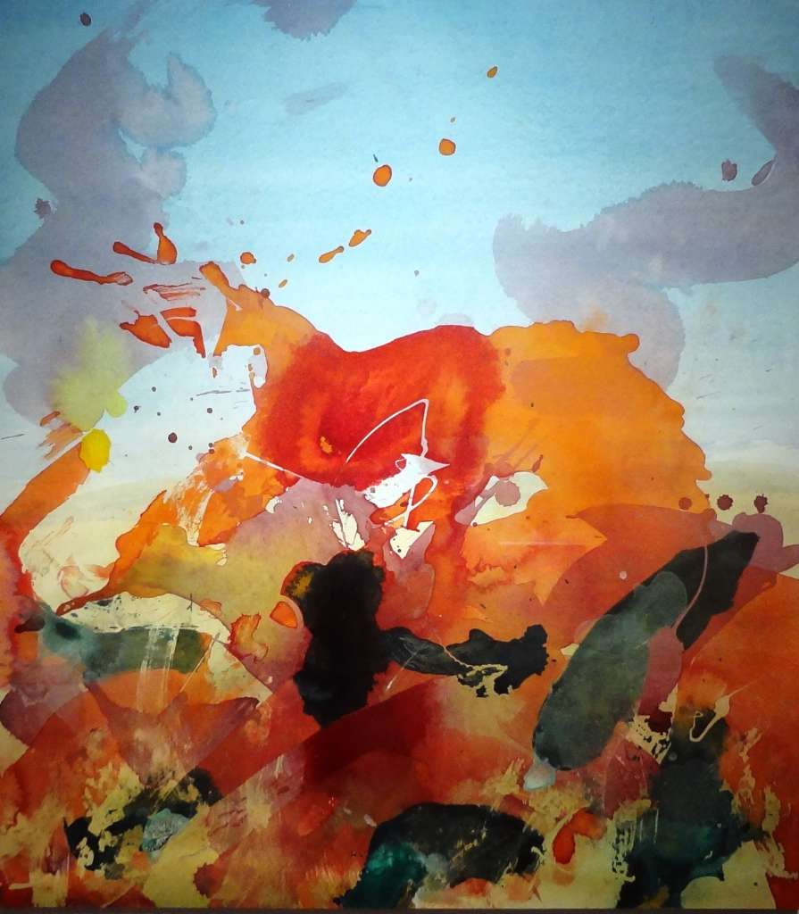

### Project Overview

Although not stated explicitly, the goal of this first project was to learn enough R markdown to present project results in a professional manner while also taking the first steps to developing an R-based project. This included downloading and accessing data files in various formats and then displaying a few descriptive statistics.

Specifically, we were charged with:

- creating a markdown file and bullet point the steps
- downloading a file from internet
- using 3 different R functions (e.g., plot, cor, pairs, etc.)
- briefly summarizing the observations
- finding an R data set
- doing three different visuals on the set (barplot, boxplot, etc.)
- finding a graph, image or grapicfile to insert into the markdown
- inserting 3 references (links)
- additionally, I set up an “R publish” account and uploaded this markdown file

The work product is this file itself.

### Input, Output Commands

1. Retrieving Files from the Internet

There are a variety of commands to allow downloading of files from the internet. If the data file is accessible directly, one can use the following sequence:

```r
system('curl -o data.csv https://data.maryland.gov/api/views/ag7x-nwtv/rows.csv?accessType=DOWNLOAD')
system('mv data.csv housing_data.csv')
```

2. Reading files
- CSV files, read.csv
- XML files
- Postgres data, read.table, source, dump dget, dput readLines, Writelines save serialize

### Miscellaneous Commands

?help(method)

demo(data.table)

getwd() -get working directory

setwd() -set working directory

http://rmarkdown.rstudio.com

### Summarize an R dataset

```r
dim(airquality)
```

```
## [1] 153   6
```

```r
head(airquality, 3)
```

```
##   Ozone Solar.R Wind Temp Month Day
## 1    41     190  7.4   67     5   1
## 2    36     118  8.0   72     5   2
## 3    12     149 12.6   74     5   3
```

```r
summary(airquality)
```

```
##      Ozone           Solar.R           Wind             Temp
##  Min.   :  1.00   Min.   :  7.0   Min.   : 1.700   Min.   :56.00
##  1st Qu.: 18.00   1st Qu.:115.8   1st Qu.: 7.400   1st Qu.:72.00
##  Median : 31.50   Median :205.0   Median : 9.700   Median :79.00
##  Mean   : 42.13   Mean   :185.9   Mean   : 9.958   Mean   :77.88
##  3rd Qu.: 63.25   3rd Qu.:258.8   3rd Qu.:11.500   3rd Qu.:85.00
##  Max.   :168.00   Max.   :334.0   Max.   :20.700   Max.   :97.00
##  NA's   :37       NA's   :7
##      Month            Day
##  Min.   :5.000   Min.   : 1.0
##  1st Qu.:6.000   1st Qu.: 8.0
##  Median :7.000   Median :16.0
##  Mean   :6.993   Mean   :15.8
##  3rd Qu.:8.000   3rd Qu.:23.0
##  Max.   :9.000   Max.   :31.0
##
```

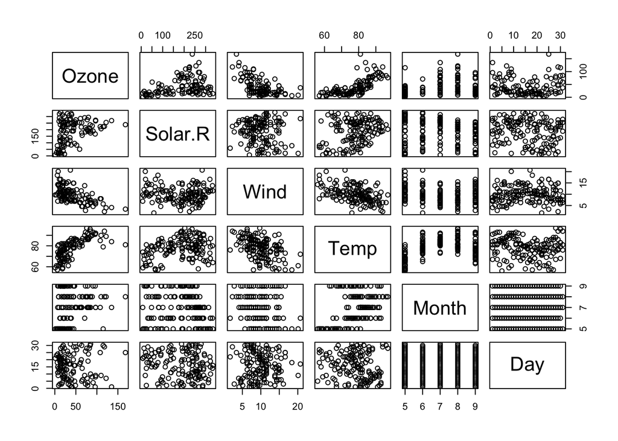

```r
pairs(airquality)
```

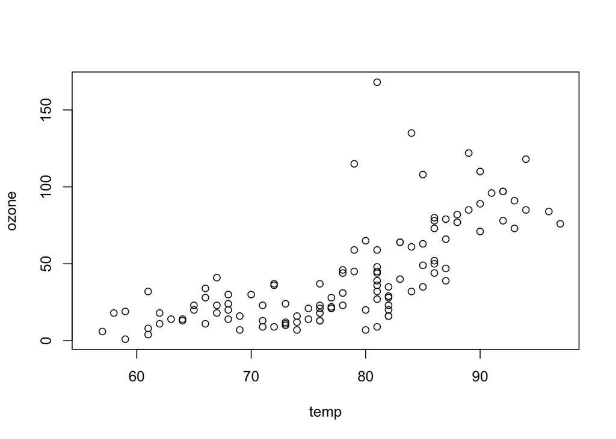

```r
ozone <- airquality$Ozone
temp <- airquality$Temp
plot(temp, ozone)
```

### About the Author

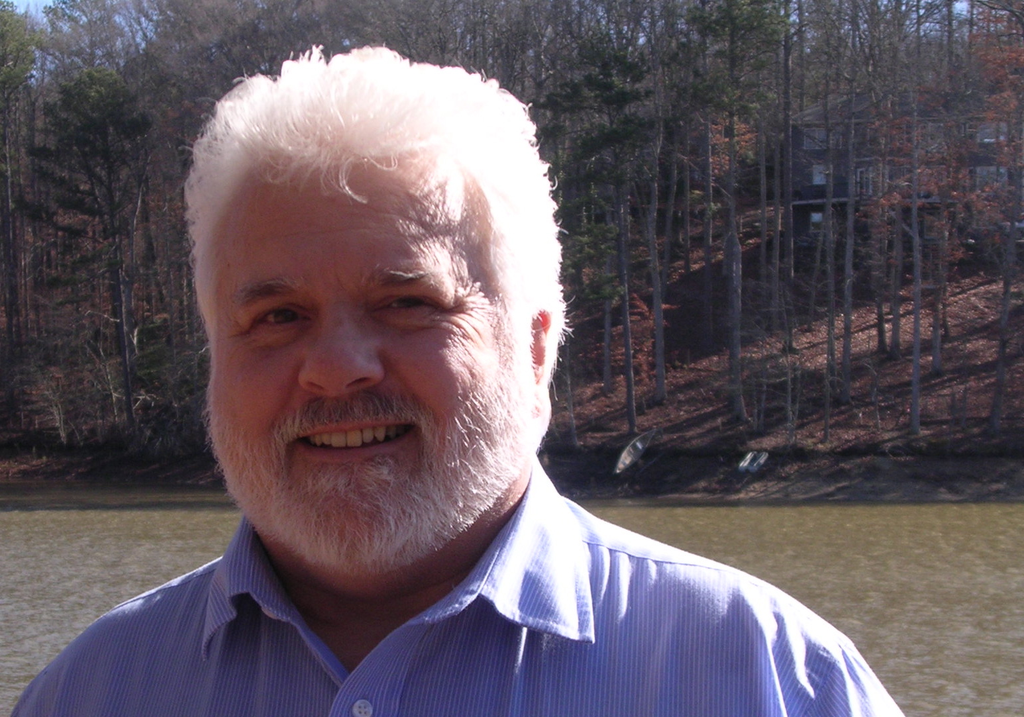

##### [Sam Skinner](https://www.linkedin.com/in/samskinnerphd) is a rambling rube in R-land, hoping to hitch a ride with fellow travelers through the R-landscape.

[figure not shown]